# R Notebook

```r
library(agricolae)
library(dplyr)
library(ggplot2)
```

# 1

# Download ‘10_tomatoes.csv’, a CRD experiment with tomato disease resistance scores

# For this experiment:

# Plot the data using boxplots

# Run an ANOVA and determine if the result is significant

# If it is significant, perform a Tukey test and identify which varieties are significantly different from each other.

```r
tomatoes <- read.csv("../data/10_tomatoes.csv")
tomatoes
```

| plot | variety | disease |
| --- | --- | --- |
| 1 | Moneymaker | 4.3326035 |
| 2 | Zebra | 5.0460797 |
| 3 | Brandywine | 6.0141374 |
| 4 | Brandywine | 5.1854654 |
| 5 | Cherokee | 4.9909376 |
| 6 | Cherokee | 4.6954093 |
| 7 | Moneymaker | 3.4203720 |
| 8 | Zebra | 2.7127780 |
| 9 | Moneymaker | 2.2154379 |
| 10 | Zebra | 5.9859896 |

[output cut: 14 more lines]

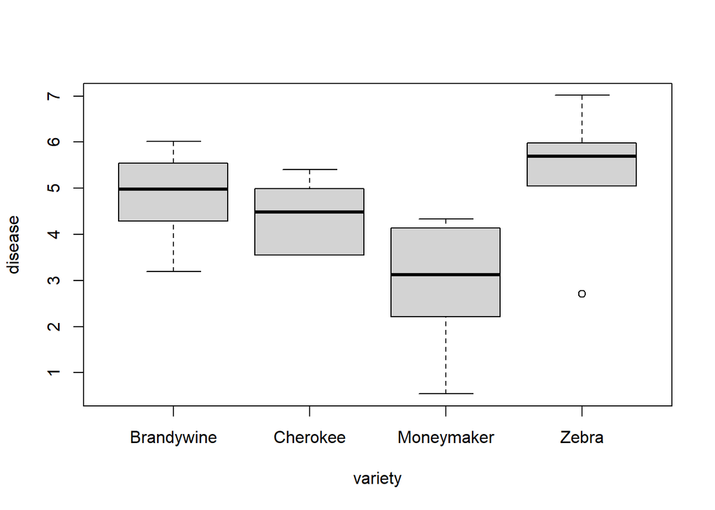

```r
boxplot(data = tomatoes, formula(disease ~ variety)) # With R standard functions
```

```r
tomanova <- aov(data = tomatoes, disease ~ variety)
summary(tomanova)
```

```
##             Df Sum Sq Mean Sq F value Pr(>F)
## variety      3  19.88   6.626   4.687 0.0123 *
## Residuals   20  28.27   1.414
## ---
## Signif. codes:  0 '***' 0.001 '**' 0.01 '*' 0.05 '.' 0.1 ' ' 1
```

# The anova is significant

```r
tuktomatoes <- HSD.test(tomanova, trt = "variety")
tuktomatoes
```

```
## $statistics
##    MSerror Df    Mean       CV      MSD
##   1.413648 20 4.37984 27.14641 1.921335
##
## $parameters
##    test  name.t ntr StudentizedRange alpha
##   Tukey variety   4         3.958293  0.05
##
## $means
##             disease       std r        se       Min      Max      Q25      Q50
## Brandywine 4.836860 1.0006617 6 0.4853947 3.1972457 6.014137 4.413337 4.985190
## Cherokee   4.412076 0.7610171 6 0.4853947 3.5482554 5.402773 3.736026 4.487991
## Moneymaker 2.913812 1.4062392 6 0.4853947 0.5423601 4.332603 2.369962 3.126953
## Zebra      5.356613 1.4479684 6 0.4853947 2.7127780 7.014337 5.176513 5.690247
##                 Q75
## Brandywine 5.458804
## Cherokee   4.917056
## Moneymaker 3.959016
## Zebra      5.942663
##
## $comparison
## NULL
##
## $groups
##             disease groups
## Zebra      5.356613      a
## Brandywine 4.836860      a
## Cherokee   4.412076     ab
## Moneymaker 2.913812      b
##
## attr(,"class")
## [1] "group"
```

# Moneymaker is significantly different from Zebra and Brandywine (both designed as group A). Cherokee is not significantly different since it shares both groups.

# 3

# 3 different extracts plus a control (=no treatment)

# 20 cages of 6 mice each (=120 total)

# Lots of shelves, each of which can hold up to 5 cages each

# All mice in a cage get the same treatment

# How should you block this experiment?

# How many DOF will you have for treatment, block, and error?

```r
treatments <- c("Extract1", "Extract2","Extract3", "None")

n_reps <- 5

rcbd_rats <- design.rcbd(trt = treatments,
                         r = n_reps,
                         )
rcbd_rats
```

```
## $parameters
## $parameters$design
## [1] "rcbd"
##
## $parameters$trt
## [1] "Extract1" "Extract2" "Extract3" "None"
##
## $parameters$r
## [1] 5
##
## $parameters$serie
## [1] 2
##
## $parameters$seed
## [1] 1157113708
##
## $parameters$kinds
## [1] "Super-Duper"
##
## $parameters[[7]]
## [1] TRUE
##
##
## $sketch
##      [,1]       [,2]       [,3]       [,4]
## [1,] "Extract1" "None"     "Extract2" "Extract3"
## [2,] "Extract3" "Extract2" "Extract1" "None"
## [3,] "Extract2" "None"     "Extract3" "Extract1"
## [4,] "Extract1" "Extract3" "None"     "Extract2"
## [5,] "Extract1" "None"     "Extract3" "Extract2"
##
## $book
##    plots block treatments
## 1    101     1   Extract1
## 2    102     1       None
## 3    103     1   Extract2
## 4    104     1   Extract3
## 5    201     2   Extract3
## 6    202     2   Extract2
## 7    203     2   Extract1
## 8    204     2       None
## 9    301     3   Extract2
## 10   302     3       None
## 11   303     3   Extract3
## 12   304     3   Extract1
## 13   401     4   Extract1
## 14   402     4   Extract3
## 15   403     4       None
## 16   404     4   Extract2
## 17   501     5   Extract1
## 18   502     5       None
## 19   503     5   Extract3
## 20   504     5   Extract2
```

```r
# 20 cages with 6 mices = 120 mices.

# 5 shelves (blocks) of 4 cages, one with each treatment.
```

# I’d use the shelves as blocks and the cages as plots for the treatments. The total observations would be 120, DOF of treatments 4-1 = 3, DOF of blocks 5 - 1 = 4 and error 4 x 3 = 12. Total DOF 20 - 1 = 19.

# The data in “10_olives.csv” contains yield data of olive plants from south Georgia.

#After harvest, it was found that the “Koroneiki” variety was mislabeled (actually a mix of several varieties), so it needs to be removed from the dataset. # Analyze the remaining varieties and determine which one(s) you should recommend for farmers to plant.

```r
olives <- read.csv("../data/10_olives.csv")
olives
```

| plot | variety | oil_yield |
| --- | --- | --- |
| plot1 | Barouni | 13.6 |
| plot2 | Ascolano | 15.3 |
| plot3 | Ascolano | 15.3 |
| plot4 | Barouni | 11.1 |
| plot5 | Mission | 12.3 |
| plot6 | Koroneiki | 16.7 |
| plot7 | Mission | 11.2 |
| plot8 | Ascolano | 14.0 |
| plot9 | Arbequina | 9.6 |
| plot10 | Koroneiki | 16.2 |

[output cut: 38 more lines]

```r
olivesnew <- olives[olives$variety != "Koroneiki", ]
unique(olivesnew$variety)
```

```
## [1] "Barouni"   "Ascolano"  "Mission"   "Arbequina" "Arbosana"
```

```r
model_olives <- aov(oil_yield ~ variety, data = olivesnew)

summary(model_olives)
```

```
##             Df Sum Sq Mean Sq F value   Pr(>F)
## variety      4  74.89   18.72   10.07 1.57e-05 ***
## Residuals   35  65.10    1.86
## ---
## Signif. codes:  0 '***' 0.001 '**' 0.01 '*' 0.05 '.' 0.1 ' ' 1
```

```r
tukolives <- HSD.test(model_olives, trt = "variety")
tukolives
```

```
## $statistics
##    MSerror Df    Mean       CV      MSD
##   1.859893 35 12.6675 10.76597 1.960473
##
## $parameters
##    test  name.t ntr StudentizedRange alpha
##   Tukey variety   5         4.065949  0.05
##
## $means
##           oil_yield       std r        se  Min  Max    Q25   Q50    Q75
## Arbequina   11.0375 1.9863373 8 0.4821687  7.8 13.4  9.675 11.20 12.450
## Arbosana    13.1625 0.8846912 8 0.4821687 11.9 14.4 12.600 12.90 13.850
## Ascolano    15.0375 0.6545173 8 0.4821687 14.0 16.0 14.600 15.30 15.325
## Barouni     12.2500 1.2569805 8 0.4821687 10.7 13.7 11.175 12.05 13.600
## Mission     11.8500 1.6008926 8 0.4821687  9.5 14.4 11.000 11.70 12.625
##
## $comparison
## NULL
##
## $groups
##           oil_yield groups
## Ascolano    15.0375      a
## Arbosana    13.1625     ab
## Barouni     12.2500     bc
## Mission     11.8500     bc
## Arbequina   11.0375      c
##
## attr(,"class")
## [1] "group"
```

# 4

# Go back to the blood treatment data from last week (08_platelets.csv).

# Plot the effects of the different treatments and determine which one(s) are significantly better than the control.

# And, if applicable, which one(s) are the best relative to control

```r
platelets <- read.csv("../data/08_platelets.csv")
platelets
```

| patient | variety | platelet_count |
| --- | --- | --- |
| patient1 | Vitality | 88.1 |
| patient2 | Booster | 81.6 |
| patient3 | Protect | 153.3 |
| patient4 | Booster | 11.6 |
| patient5 | Vitality | 74.4 |
| patient6 | Booster | 31.2 |
| patient7 | Vitality | 26.7 |
| patient8 | Booster | 95.5 |
| patient9 | Protect | 87.3 |
| patient10 | Vitality | 22.0 |

[output cut: 86 more lines]

```r
model_platelet <- aov(platelet_count ~ variety , data = platelets) # platelets is explained by the column treatment and the data is platelets

summary(model_platelet)
```

```
##             Df Sum Sq Mean Sq F value Pr(>F)
## variety      3  41136   13712   5.405 0.0018 **
## Residuals   92 233395    2537
## ---
## Signif. codes:  0 '***' 0.001 '**' 0.01 '*' 0.05 '.' 0.1 ' ' 1
```

```r
tukplatelet <- HSD.test(model_platelet, trt = "variety")
tukplatelet
```

```
## $statistics
##    MSerror Df     Mean       CV      MSD
##   2536.902 92 77.21146 65.23342 38.04531
##
## $parameters
##    test  name.t ntr StudentizedRange alpha
##   Tukey variety   4         3.700452  0.05
##
## $means
##          platelet_count      std  r       se   Min   Max    Q25   Q50    Q75
## Booster        56.44583 50.52677 24 10.28126 -53.7 166.3 22.775 53.80  95.65
## none           98.96250 60.29146 24 10.28126   7.2 225.6 46.125 93.65 136.95
## Protect        96.83333 38.29094 24 10.28126  11.1 173.7 72.275 91.95 110.65
## Vitality       56.60417 49.93394 24 10.28126 -49.7 143.8 35.850 63.30  88.20
##
## $comparison
## NULL
##
## $groups
##          platelet_count groups
## none           98.96250      a
## Protect        96.83333      a
## Vitality       56.60417      b
## Booster        56.44583      b
##
## attr(,"class")
## [1] "group"
```

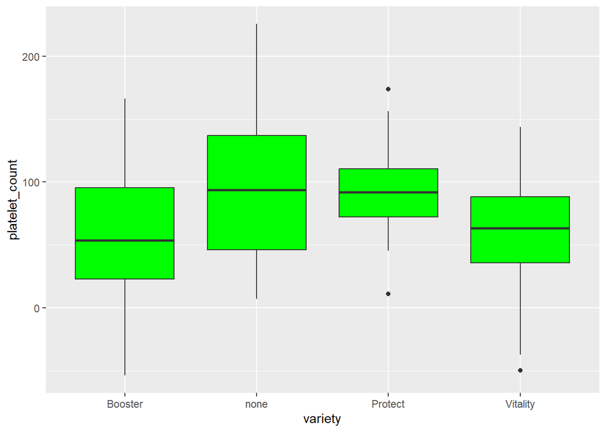

```r
# With ggplot package.

ploot <- ggplot(platelets, aes(
  x = variety,
  y = platelet_count
)) +
  geom_boxplot(fill = "green")
ploot
```

# The ANOVA showed that the control and the Protect treatment have no significant difference between both, but are significantly different than the other treatments Vitality and Booster. The median of both control and Protect treatment are simillar suggesting that both can be used for good results.

# 5

# Using the random seed 456, make an RCBD in R with the following parameters, then print it off to show it worked:

# 4 treatments (Low, Mid, High, and None)

# 8 replicates of each treatment

# Save the fieldbook to an external file and verify it saved correctly.

# “Fieldbook” = 1 plot per row, not the physical layout

# For this experiment, how many DOF did you lose relative to a CRD?

```r
set.seed(456)

treatments <- c("Low", "Mid", "High", "None")
n_reps <- 8 # Number of replicates


rcbd <- design.rcbd(
  trt = treatments,
  r = n_reps
)

fieldbook <- rcbd$book

fieldbook
```

| plots | block | treatments |
| --- | --- | --- |
| 101 | 1 | None |
| 102 | 1 | High |
| 103 | 1 | Low |
| 104 | 1 | Mid |
| 201 | 2 | None |
| 202 | 2 | Mid |
| 203 | 2 | Low |
| 204 | 2 | High |
| 301 | 3 | Mid |
| 302 | 3 | High |

[output cut: 22 more lines]

```r
# write.csv(fieldbook,
#           file = "../output/fieldbook.csv")
```

[figure not shown]

# for treatments we have 4 total treatments so 3 DOF, for blocks, we have 8 blocks, so 7 DOF, and multiplicating treatments with blocks we will have 21 DOF for error.

# RCBD error df = 21.

# CRD error df = 28.

# RCBD loses 7 error degrees of freedom